# Appendix 3

Katie Florko

30/11/2022

# Overview

This document contains the code from “*A comparison of statistical models used to characterize species-habitat associations with movement data*”. This code includes the case study analysis on ringed seal movement in eastern Hudson Bay, Canada.

# Prepare

## Load packages

```r
library(tidyverse)
library(lubridate)
library(rnaturalearth)
library(rgdal)
library(raster)
library(amt)
library(momentuHMM)
```

## Fish data

Next we load in the fish data. This is a subset of the data from Florko et al. (2021).

```r
setwd("~/Documents/R/PhD/seal-movement/data")
fish <- read.csv("fish_2012.csv")
head(fish)
```

```
##          x        y capelin arccod nsandlance psandlance rbsmelt shsculpin
## 1 -1031670 -1016109       0      0          0          0       0         0
## 2 -1031670 -1066109       0      0          0          0       0         0
## 3 -1031670 -1116109       0      0          0          0       0         0
## 4 -1031670  -116109       0      0          0          0       0         0
## 5 -1031670 -1166109       0      0          0          0       0         0
## 6 -1031670 -1216109       0      0          0          0       0         0
##   astagsculpin mustsculpin preydiv
## 1            0           0       1
## 2            0           0       1
## 3            0           0       1
## 4            0           0       1
## 5            0           0       1
## 6            0           0       1
```

Visualize the fish data.

```r
# prepare fish data
## long data frame
fishl <- fish %>%
  pivot_longer(cols = c(capelin, arccod, nsandlance), names_to = "species", values_to = "biomass")

## raster
fish_raster <- rasterFromXYZ(fish, crs = CRS("+proj=longlat +ellps=WGS84 +datum=WGS84 +no_defs"))

#prepare world data
## List of azimuthal equal area - HudsonBay
natearth <- ne_countries(scale = "medium",returnclass = "sp")
natearth <- natearth[which(natearth$continent!="Antarctica"),]
nat_trans <- spTransform(natearth,CRS("+proj=laea +lat_0=60 +lon_0=-85 +x_0=0 +y_0=0 +datum=WGS84 +units=m +no_defs +ellps=WGS84 +towgs84=0,0,0"))
```

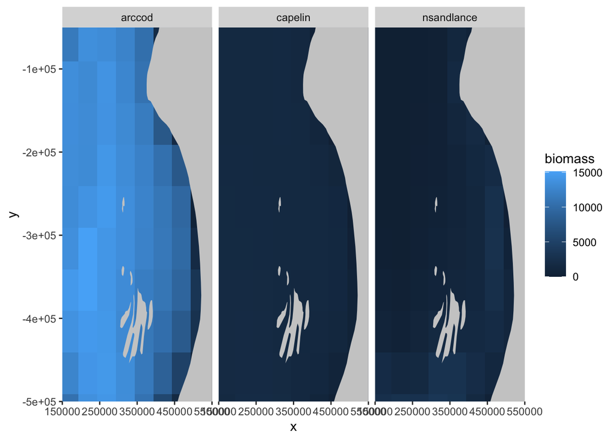

```r
#plot fish map, note that the scale is the same for each prey
ggplot() +
  geom_tile(data = fishl, aes(x = x,y = y,fill = biomass)) +
  geom_polygon(data = nat_trans, aes(x=long,y=lat,group=group), fill = "grey80") +
  coord_cartesian(xlim = c(150000,550000), ylim = c(-500000,-50000), expand = F) +
  facet_grid(.~species)
```

## Seal data

Next we load in the seal movement data. This is a subset of the data from Florko et al. (in review).

```r
setwd("~/Documents/R/PhD/seal-movement/data")
seal <- read.csv("seal_track_m.csv")
head(seal)
```

```
##         id                date        x         y
## 1 116484_1 2012-10-29 14:00:00 357940.9 -368949.6
## 2 116484_1 2012-10-30 14:00:00 371620.6 -352893.0
## 3 116484_1 2012-10-31 14:00:00 388697.4 -361720.7
## 4 116484_1 2012-11-01 14:00:00 399448.1 -356623.1
## 5 116484_1 2012-11-02 14:00:00 411825.3 -349501.5
## 6 116484_1 2012-11-03 14:00:00 407736.7 -372638.1
```

```r
summary(seal)
```

```
##       id                date                 x                y
##  Length:183         Length:183         Min.   :211564   Min.   :-455311
##  Class :character   Class :character   1st Qu.:308902   1st Qu.:-285850
##  Mode  :character   Mode  :character   Median :379935   Median :-242105
##                                        Mean   :372805   Mean   :-251256
##                                        3rd Qu.:427774   3rd Qu.:-196491
##                                        Max.   :492269   Max.   :-136952
```

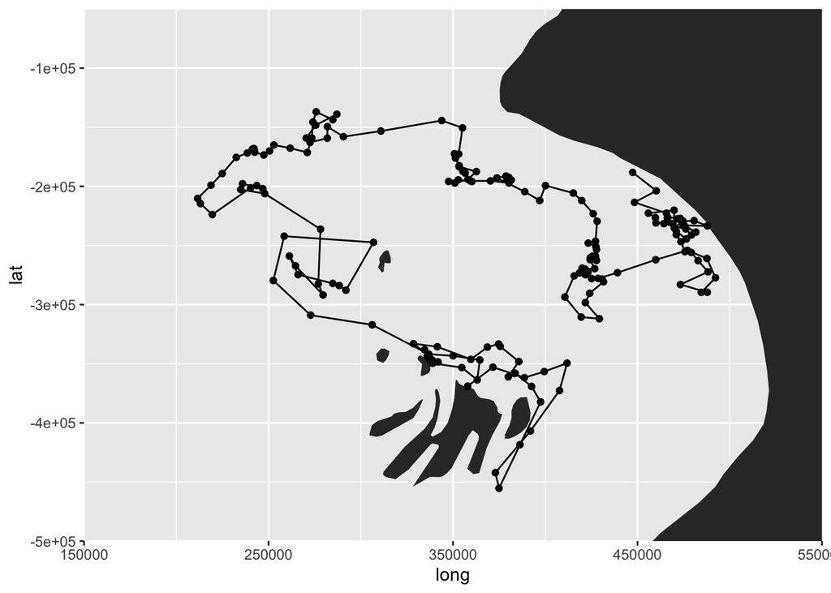

```r
# ensure the data is in the correct format
seal <- seal %>%
  mutate(id = as.character(id),
         date = ymd_hms(date))

# plot
ggplot() +
  geom_polygon(data = nat_trans, aes(x=long,y=lat,group=group)) +
  geom_point(data=seal, aes(x=x, y=y)) +
  geom_path(data=seal, aes(x=x, y=y)) +
  coord_cartesian(xlim = c(150000,550000), ylim = c(-500000,-50000),
                  expand = F)
```

# Fit models

#1. RSF Fit using amt (Signer et al. 2019)

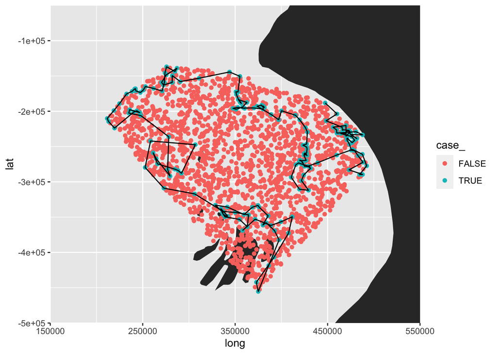

```r
# generate availability sample
set.seed(2023)
data_rsf <- seal %>%
  make_track(x, y, date) %>%
  random_points() # default is ten times as many available points as observed points

# plot used vs available
ggplot() +
  geom_polygon(data = nat_trans, aes(x=long,y=lat,group=group)) +
  geom_point(data=data_rsf, aes(x=x_, y=y_, color = case_)) +
  geom_path(data=seal, aes(x=x, y=y)) +
  coord_cartesian(xlim = c(150000,550000), ylim = c(-500000,-50000), expand = F)
```

```r
# extract fish covariates
data_rsf <- data_rsf %>%
  extract_covariates(fish_raster)

# fit rsf
rsf1 <- data_rsf %>%
  amt::fit_rsf(case_ ~ capelin + arccod + nsandlance, model = TRUE)

# see parameter estimates
summary(rsf1)
```

```
##
## Call:
## stats::glm(formula = formula, family = stats::binomial(link = "logit"),
##     data = data, model = TRUE)
##
## Deviance Residuals:
##     Min       1Q   Median       3Q      Max
## -0.7611  -0.4424  -0.4136  -0.3726   2.4840
##
## Coefficients:
##               Estimate Std. Error z value Pr(>|z|)
## (Intercept)  2.7612770  1.1388871   2.425   0.0153 *
## capelin     -0.0009641  0.0010867  -0.887   0.3750
## arccod      -0.0002710  0.0001376  -1.969   0.0489 *
## nsandlance  -0.0004531  0.0002303  -1.968   0.0491 *
## ---
## Signif. codes:  0 '***' 0.001 '**' 0.01 '*' 0.05 '.' 0.1 ' ' 1
##
## (Dispersion parameter for binomial family taken to be 1)
##
##     Null deviance: 1226.5  on 2012  degrees of freedom
## Residual deviance: 1196.2  on 2009  degrees of freedom
## AIC: 1204.2
##
## Number of Fisher Scoring iterations: 5
```

#2. SSF Fit using amt (Signer et al. 2019)

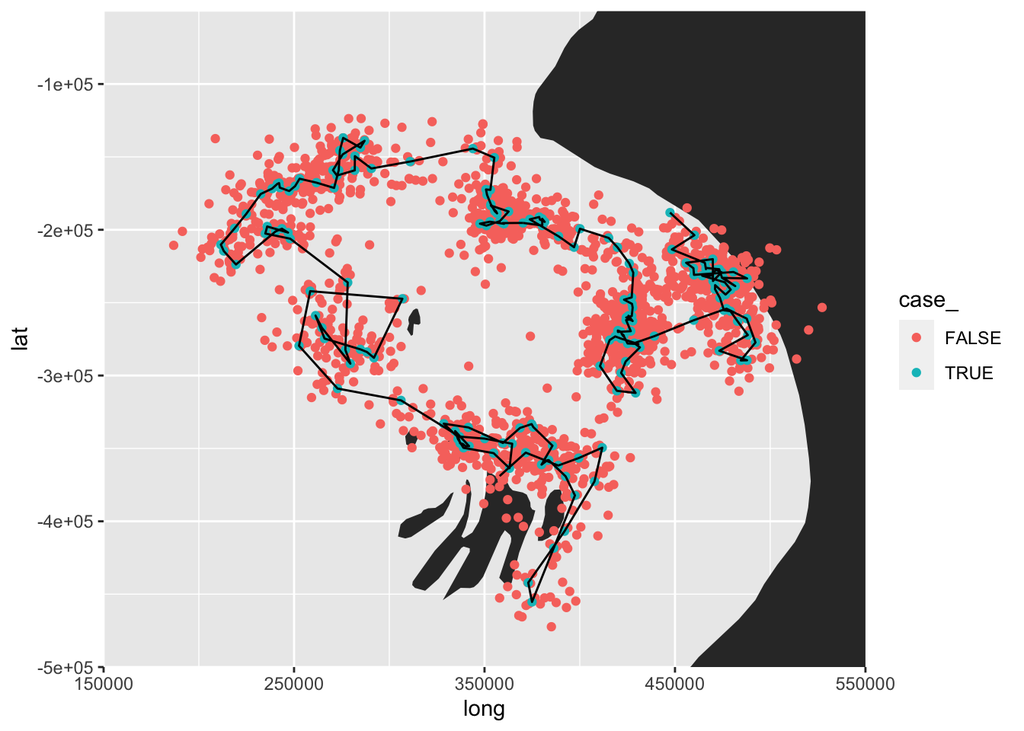

```r
# generate availabilty sample
set.seed(2023)
data_ssf <- seal %>%
  make_track(x, y, date) %>%
  steps() %>%
  random_steps(n_control = 10) %>%
  arrange(case_)

# plot used vs available
ggplot() +
  geom_polygon(data = nat_trans, aes(x=long,y=lat,group=group)) +
  geom_point(data=data_ssf, aes(x=x2_, y=y2_, color = case_)) +
  geom_path(data=seal, aes(x=x, y=y)) +
  coord_cartesian(xlim = c(150000,550000), ylim = c(-500000,-50000), expand = F)
```

```r
# extract fish covariates
data_ssf <- data_ssf %>%
  extract_covariates(fish_raster)

# fit ssf
ssf1 <- data_ssf %>%
  fit_clogit(case_ ~ capelin + arccod + nsandlance +
               strata(step_id_))

# see parameter estimates
summary(ssf1)
```

```
## Call:
## coxph(formula = Surv(rep(1, 2002L), case_) ~ capelin + arccod +
##     nsandlance + strata(step_id_), data = data, method = "exact")
##
##   n= 2002, number of events= 182
##
##                  coef  exp(coef)   se(coef)      z Pr(>|z|)
## capelin    -0.0026658  0.9973378  0.0024099 -1.106    0.269
## arccod      0.0003922  1.0003922  0.0002864  1.369    0.171
## nsandlance  0.0001074  1.0001074  0.0003709  0.290    0.772
##
##            exp(coef) exp(-coef) lower .95 upper .95
## capelin       0.9973     1.0027    0.9926     1.002
## arccod        1.0004     0.9996    0.9998     1.001
## nsandlance    1.0001     0.9999    0.9994     1.001
##
## Concordance= 0.53  (se = 0.016 )
## Likelihood ratio test= 2.21  on 3 df,   p=0.5
## Wald test            = 2.15  on 3 df,   p=0.5
## Score (logrank) test = 2.16  on 3 df,   p=0.5
```

# 3. iSSF

Fit using amt (Signer et al. 2019)

```r
# transform movement covariates
data_issf <- data_ssf %>%
  mutate(cos_ta = cos(ta_),
         log_sl = log(sl_))

# fit ssf
issf1 <- data_issf %>%
  fit_clogit(case_ ~ capelin + arccod + nsandlance +
               log_sl + cos_ta +
               strata(step_id_))

# see parameter estimates
summary(issf1)
```

```
## Call:
## coxph(formula = Surv(rep(1, 2002L), case_) ~ capelin + arccod +
##     nsandlance + log_sl + cos_ta + strata(step_id_), data = data,
##     method = "exact")
##
##   n= 2001, number of events= 181
##    (1 observation deleted due to missingness)
##
##                  coef  exp(coef)   se(coef)      z Pr(>|z|)
## capelin    -0.0026954  0.9973083  0.0024278 -1.110    0.267
## arccod      0.0003950  1.0003951  0.0002886  1.369    0.171
## nsandlance  0.0001021  1.0001021  0.0003748  0.272    0.785
## log_sl     -0.0218461  0.9783908  0.0820883 -0.266    0.790
## cos_ta      0.0550609  1.0566049  0.1147096  0.480    0.631
##
##            exp(coef) exp(-coef) lower .95 upper .95
## capelin       0.9973     1.0027    0.9926     1.002
## arccod        1.0004     0.9996    0.9998     1.001
## nsandlance    1.0001     0.9999    0.9994     1.001
## log_sl        0.9784     1.0221    0.8330     1.149
## cos_ta        1.0566     0.9464    0.8439     1.323
##
## Concordance= 0.51  (se = 0.026 )
## Likelihood ratio test= 2.57  on 5 df,   p=0.8
## Wald test            = 2.47  on 5 df,   p=0.8
## Score (logrank) test = 2.48  on 5 df,   p=0.8
```

#4. HMM Fit using momentuHMM (McClintock and Michelot, 2018)

```
## Decoding state sequence... DONE
```

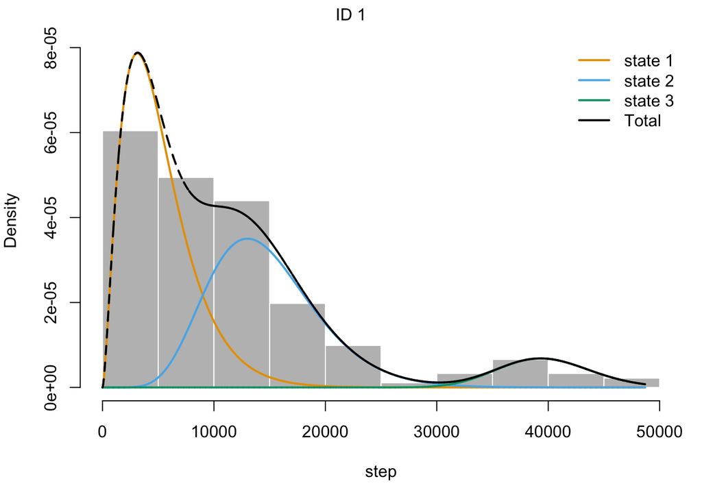

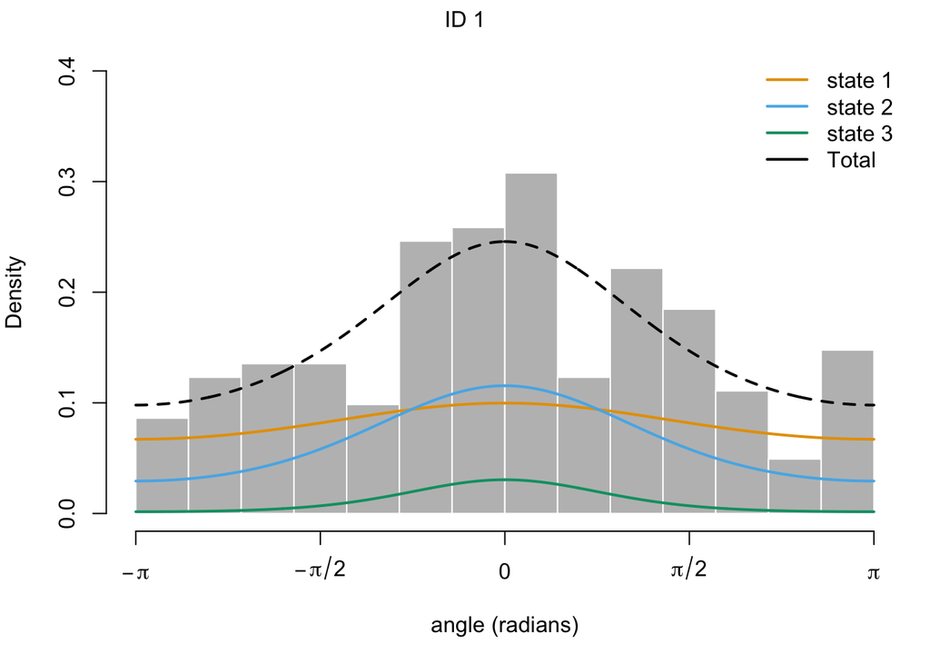

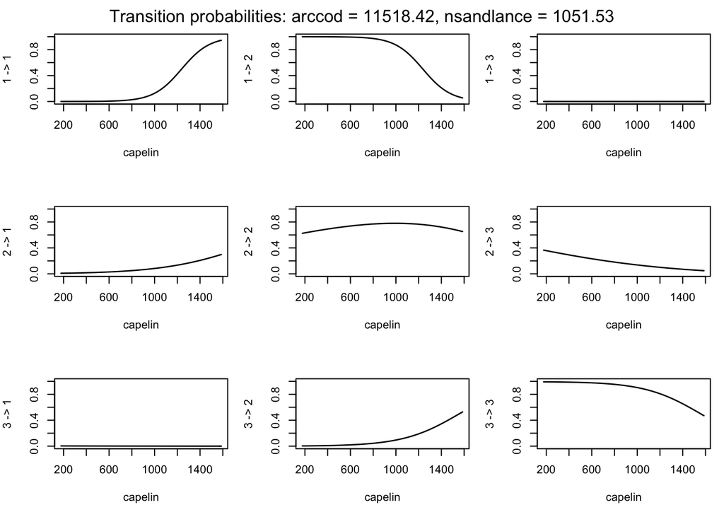

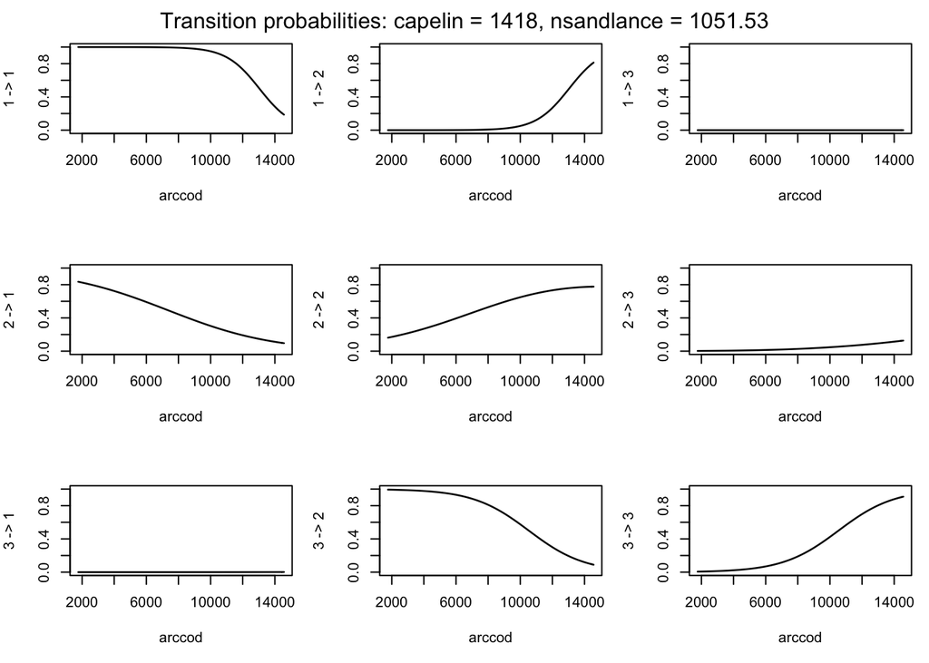

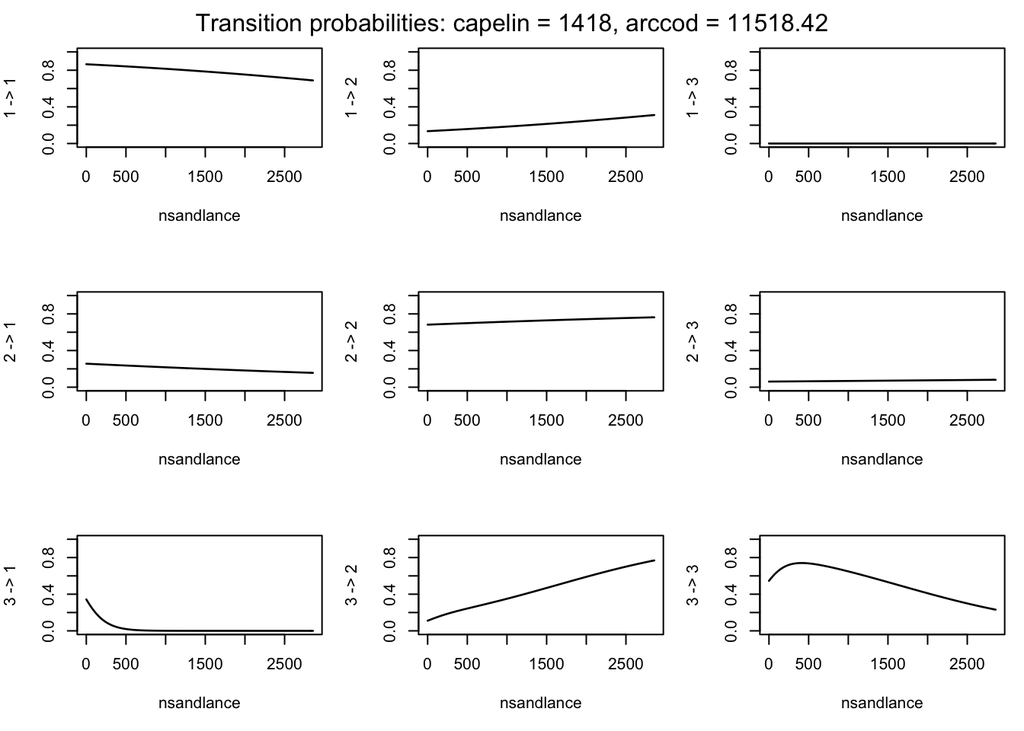

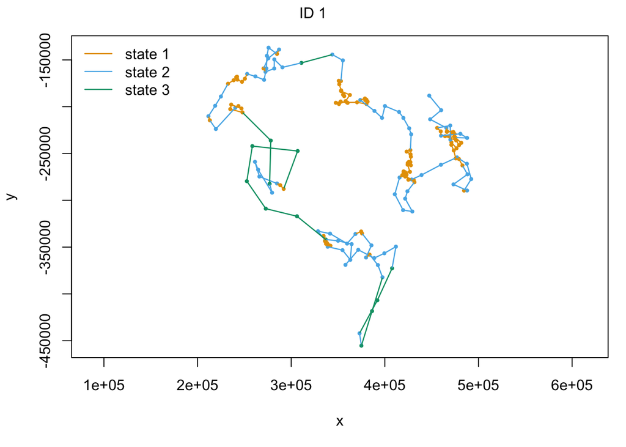

```r
# prepare dataset
data_hmm <- seal %>%
  make_track(x, y, date) %>%
  extract_covariates(fish_raster) %>%
    mutate(ID = 1,
         x = x_,
         y = y_,
         date = t_) %>%
  dplyr::select(ID, x, y, date, capelin, arccod, nsandlance) %>%
  as.data.frame()

# convert into momentuHMM format
data_hmm <- momentuHMM::prepData(data_hmm, coordNames = c("x", "y"),
                                 type = "UTM",
                                 covNames = c("capelin", "arccod", "nsandlance"))

# define initial parameters
nbStates <- 3 # number of states
stepDist <- "gamma" # step distribution
angleDist <- "vm" # turning angle distribution

mu0 <- c(5000, 14000, 40000) # mean step length for each state
sigma0 <- c(3000,  5000, 4000) # sd step length for each state
stepPar0 <- c(mu0, sigma0)
kappa0 <- c(0.35, 0.55, 1.5) # turning angle for each state

formula = ~ capelin + arccod + nsandlance # identify covariates

# fit basic 3-state hmm
set.seed(2023)
hmm1 <- momentuHMM::fitHMM(data=data_hmm, nbStates=nbStates,
            dist=list(step=stepDist,angle=angleDist),
            Par0=list(step=stepPar0,angle=kappa0))

# retrieve parameters to refine model
Par0_hmm1 <- momentuHMM::getPar0(hmm1, formula=formula)

# fit a refined hmm with parameters from above
set.seed(2023)
hmm2 <- momentuHMM::fitHMM(data=data_hmm, nbStates=3,
            dist=list(step=stepDist,angle=angleDist),
            Par0=Par0_hmm1$Par,
            delta0 = Par0_hmm1$delta,
            beta0 = Par0_hmm1$beta,
            formula=formula)


# plot model
plot(hmm2)
```

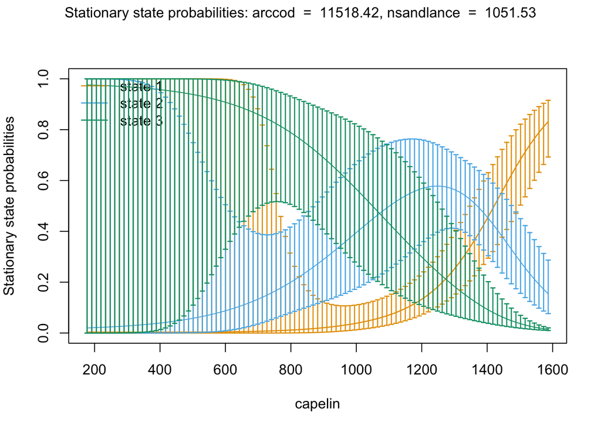

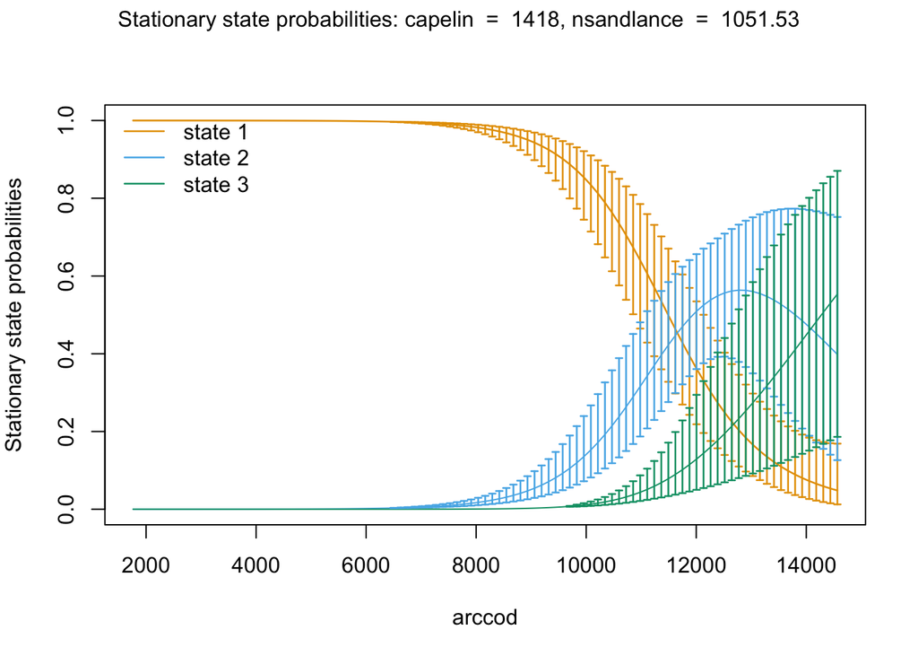

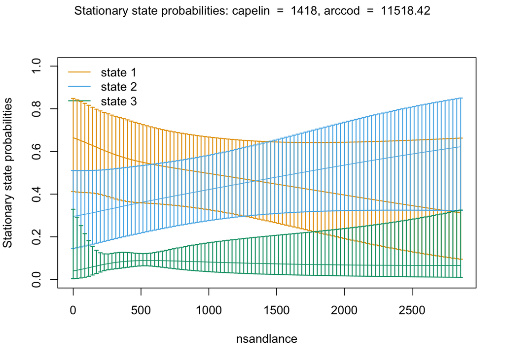

```r
# plot stationary probabilities for each prey
momentuHMM::plotStationary(hmm2, plotCI= TRUE)
```

# Plot prediction maps

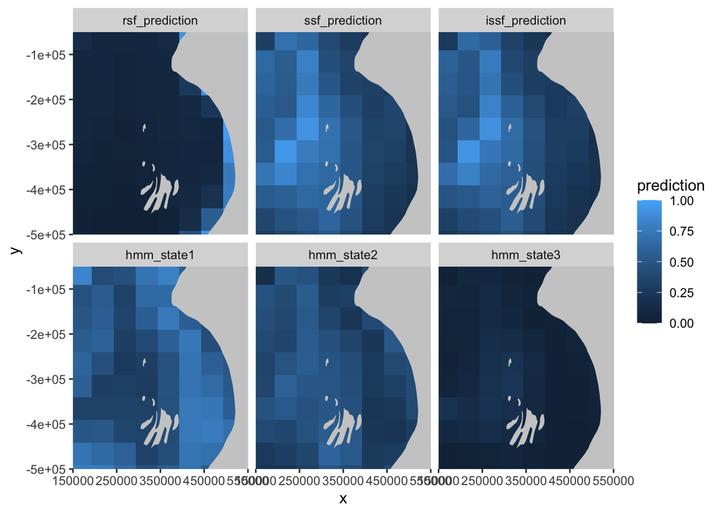

```r
# prep the fish data
newfish <- fish_raster %>%
  rasterToPoints() %>%
  as.data.frame() %>%
  filter(x > 100000 & x < 600000 & y > -550000 & y < 0)

# range function
range01 <- function(x){(x-min(x))/(max(x)-min(x))}

# PREDICTIONS
#-------------------------- RSF
modcoef <- summary(rsf1)$coef
x <- exp(modcoef[1] +
           (modcoef[2] * newfish$capelin) +
           (modcoef[3] * newfish$arccod) +
           (modcoef[4] * newfish$nsandlance))
x <- x / (1 + x)
newfish$rsf_prediction <- range01(x)

#-------------------------- SSF
ssf2 <- glm(relevel(as.factor(case_), ref = "FALSE") ~ # the GLM function returns the coefficients in an easier-to-wrangle format
              capelin + arccod + nsandlance +
              strata(step_id_),
      family = "binomial",
      data = data_ssf)

modcoef <- summary(ssf2)$coef
x <- exp(modcoef[1] +
           (modcoef[2] * newfish$capelin) +
           (modcoef[3] * newfish$arccod) +
           (modcoef[4] * newfish$nsandlance))
x <- x / (1 + x)
newfish$ssf_prediction <- range01(x)

#-------------------------- iSSF
issf2 <- glm(relevel(as.factor(case_), ref = "FALSE") ~ # the GLM function returns the coefficients in an easier-to-wrangle format
               capelin + arccod + nsandlance + cos_ta + log_sl +
               strata(step_id_),
      family = "binomial",
      data = data_issf)

modcoef <- summary(issf2)$coef
x <- exp(modcoef[1] +
           (modcoef[2] * newfish$capelin) +
           (modcoef[3] * newfish$arccod) +
           (modcoef[4] * newfish$nsandlance)) # **MARIE** I'm not sure how to incorporate step length and turning angle
x <- x / (1 + x)
newfish$issf_prediction <- range01(x)

#-------------------------- HMM
# grab stationary probabilities
x <- as.data.frame(momentuHMM::stationary(hmm2, data.frame(capelin = newfish$capelin, arccod = newfish$arccod, nsandlance = newfish$nsandlance)))
newfish$hmm_state1 <- x$state.1
newfish$hmm_state2 <- x$state.2
newfish$hmm_state3 <- x$state.3

#-------------------------- all together plot
newfish_long <- newfish %>%
  pivot_longer(cols = rsf_prediction:hmm_state3,
               names_to = "model", values_to = "prediction") %>%
  mutate(across(model, factor, levels=c("rsf_prediction","ssf_prediction","issf_prediction", "hmm_state1", "hmm_state2", "hmm_state3")))

ggplot() +
  geom_tile(data = newfish_long, aes(x = x, y = y, fill = prediction)) +
  geom_polygon(data = nat_trans, aes(x=long,y=lat,group=group), fill = "grey80") +
  coord_cartesian(xlim = c(150000,550000), ylim = c(-500000,-50000), expand = F) +
  facet_wrap(~model)
```

# References

Florko, K.R.N., Tai, T.C., Cheung, W.W.L., Sumaila, U.R., Ferguson, S.H., Yurkowski, D.J., Auger-Méthé, M. 2021. Predicting how climate change threatens the prey base of Arctic marine predators. Ecology Letters, 24: 2563-2575.

Florko, K.R.N., Shuert, C.R., Cheung, W.W.L., Ferguson, S.H., Jonsen, I.D., Rosen, D.A.S., Sumaila, U.R., Tai, T.C., Yurkowski, D.J., Auger-Méthé, M. Linking movement and dive data to prey distribution models: new insights in foraging behavior and potential pitfalls of movement analyses. bioRxiv doi: 10.1101/2022.11.17.516808

McClintock, B.T., Michelot, T. 2018. momentuHMM: R package for generalized hidden markov models of animal movement. Methods Ecol. Evolut. 9, 1518-1530.

Signer, J., J. Fieberg, and T. Avgar. 2019. Animal movement tools (amt): R package for managing tracking data and conducting habitat selection analyses. Ecology and Evolution 9:880–890.